# R Notebook

Graphs should have white backgrounds, and use colour sparingly. There should be faint grid lines. Font sizes should be ~12pt although titles should be slightly larger and axis labels can be slightly smaller. All plots should use colours from the following company colour scheme. # Data

```r
library(tidyverse)
library(CodeClanData)

revenue <- qb_revenue_breakdown
sales <- qb_monthly_sales
competitors <- qb_competitors
device_data <- qb_device_data

col_scheme <- c("#E89FE9", "#50434F", "#B6A7B5", "#F9A472", "#BD7040")
```

# Q1.Take the data in the dataset qb_revenue_breakdown and make a stacked bar chart showing the sources of revenue across the two years in the dataset.

```r
head(revenue)
```

|  | Product | Year | Revenue |
| --- | --- | --- | --- |
| 1 | Trackers | 2019 | 8994 |
| 2 | Smart Watches | 2019 | 12003 |
| 3 | Accessories | 2019 | 5250 |
| 4 | Subscription Services | 2019 | 3750 |
| 5 | Trackers | 2018 | 8004 |
| 6 | Smart Watches | 2018 | 11000 |

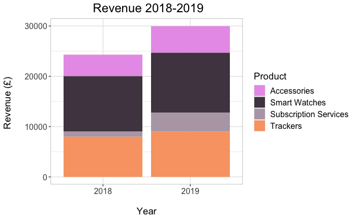

```r
ggplot(revenue) +
  aes(x = Year, y = Revenue, fill = Product) +
  geom_col() +
  labs(x = "\n Year ",
       y= "Revenue (£) \n",
       title = " Revenue 2018-2019") +
  scale_fill_manual(values = col_scheme) +
  theme(panel.background = element_rect(fill = "white"),
        panel.border = element_rect(fill = NA, colour = "grey70"),
        panel.grid = element_line(colour = "grey90"),
        axis.text = element_text(size = 12),
        axis.title = element_text(size = 14),
        legend.text = element_text(size = 12),
        legend.title = element_text(size = 14),
       plot.title = element_text(size = 18, hjust = 0.5))
```

There has been a considerable increase in streaming services.

# Q2. Make a line chart showing monthly sales of the “flagship product” - the KwikBit Unit1 - over the last year. This data is inside qb_monthly_sales, but you will need to use subset.

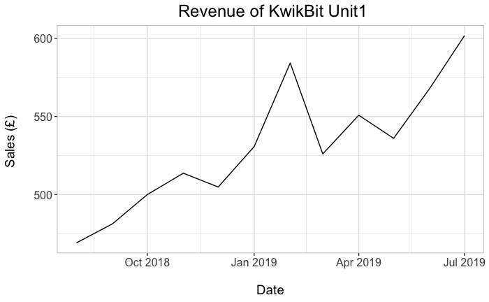

```r
sales %>%
  filter(Cashflow == "Kwikbit Unit 1 Sales") %>%
  ggplot()+
  aes(x = Date, y = Amount)+
  geom_line() +
   labs(x = "\n Date ",
       y= "Sales (£) \n",
       title = " Revenue of KwikBit Unit1") +
    scale_fill_manual(values = col_scheme) +
  theme(panel.background = element_rect(fill = "white"),
        panel.border = element_rect(fill = NA, colour = "grey70"),
        panel.grid = element_line(colour = "grey90"),
        axis.text = element_text(size = 12),
        axis.title = element_text(size = 14),
        legend.text = element_text(size = 12),
        legend.title = element_text(size = 14),
       plot.title = element_text(size = 18, hjust = 0.5))
```

# Q3. Make a line chart showing monthly revenue and costs over the last year. This data is also in qb_monthly_sales.

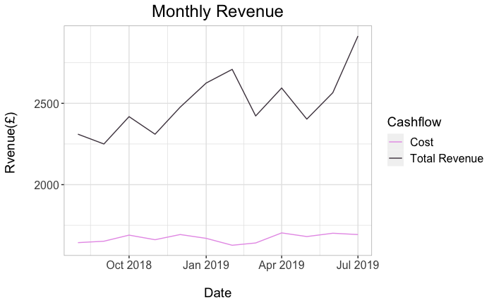

```r
sales %>%
  filter(Cashflow != "Kwikbit Unit 1 Sales") %>%
  ggplot()+
  aes(x = Date, y = Amount, colour = Cashflow)+
    labs(x = "\n Date ",
       y= "Rvenue(£) \n",
       title = "Monthly Revenue") +
  geom_line() +
    scale_colour_manual(values = col_scheme) +
  theme(panel.background = element_rect(fill = "white"),
        panel.border = element_rect(fill = NA, colour = "grey70"),
        panel.grid = element_line(colour = "grey90"),
        axis.text = element_text(size = 12),
        axis.title = element_text(size = 14),
        legend.text = element_text(size = 12),
        legend.title = element_text(size = 14),
       plot.title = element_text(size = 18, hjust = 0.5))
```

Costs have remained steady over time but monthly revenue has increased.